# Final Project

Stats 506, F20

Yanyu Long, longyyu@umich.edu

December 15, 2020

## Introduction

Over the last century, constructing methods and techniques have become more advanced, constructing codes have become increasingly stringent, and new building materials have been developed to meet the evolving needs. It can be interesting to compare the major wall materials of US commercial buildings constructed at different time periods.

This report attempts to answer the following questions:

## Data / Methods

This project uses the *2012 US Commercial Building Energy Consumption Survey (CBECS) survey microdata* published by the U.S. Energy Information Administration (EIA). The *variable and response codebook* is also needed to decode the variables.

Below is an outline of the computation process.

- Point estimates of `percent of wall materials` are estimated from the full sample using the full sample building weight (`FINALWT`). The 95% confidence intervals are constructed based on the replicate sub-samples by using the replicate weights (`FINALWT1 – FINALWT197`).
- As per the [documentation](https://www.eia.gov/consumption/commercial/data/2012/pdf/user_guide_public_use_aug2016.pdf), variances of estimations are estimated by $\hat{V} (\hat{\theta}) = \sum_{r=1}^R \alpha_r(\hat{\theta}_r - \hat{\theta})^2$, where $\alpha_r = 1$.
- 95% Confidence intervals are constructed using $\hat{\theta} \pm \Phi^{-1}(.975)\sqrt{\hat{V}(\hat{\theta})}$.
- The above analysis is first conducted at the aggregated level (grouped by `year of construction` only), then at the regional level (further grouped by `census region`).

The data files and source code can be found in [this GitHub repository](https://github.com/longyyu/Stats506_FinalProj).

## Results

### Figure

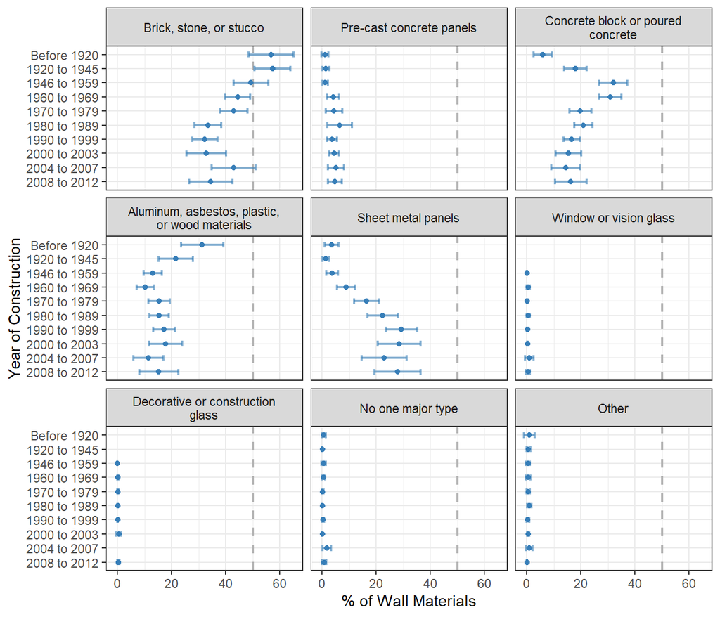

**Fig 1.** % of wall material types by year of construction

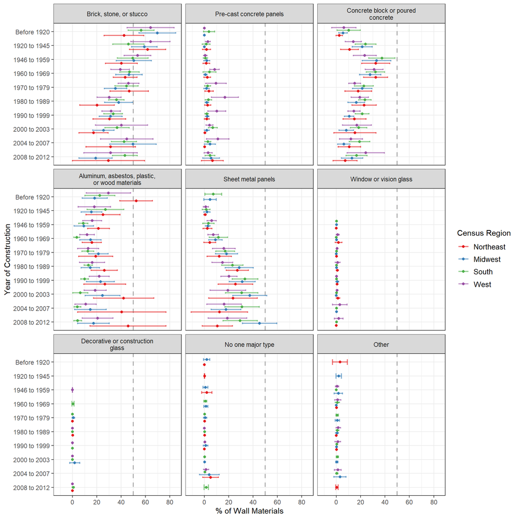

**Fig 2.** % of wall material types by year of construction and census region